# Question

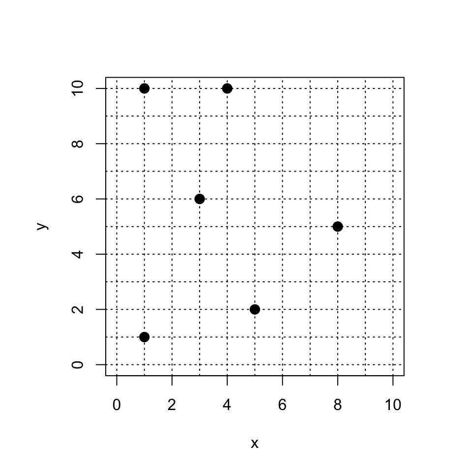

- Is $y$ a function of $x$? ##ANSWER1##
- Is $x$ a function of $y$? ##ANSWER2##
- Do we have a one-to-one function? ##ANSWER3##

## Answerlist

- Yes
- No
- Yes
- No
- Yes
- No

# Solution

It is best to visualize the vertical line test and the horizontal line test. If you can draw a vertical line through 2 (or more) points, then $y$ is not a function of $x$. If you can draw a horizontal line through 2 (or more) points, then $x$ is not a function of $y$.

An $x$ value repeats with different $y$ values, so $y$ is not a function of $x$. The graph fails the vertical line test. For example: (1, 10) and (1, 1)

Also, a $y$ value repeates with different $x$ values, so $x$ is not a function of $y$. The graph fails the horizontal line test. For example: (1, 10) and (4, 10)

We would need both to be function of the other to have a one-to-one function. Neither is, so we don’t even have a function in either direction.

# Meta-information

extype: cloze exclozetype: schoice|schoice|schoice exsolution: 01|01|01 exname: are_points_a_function